## Let scrape the skyscrapers using Scrapy

[figure not shown]

[The Skyscraper Center](https://skyscrapercenter.com) publishes various information about world's skyscrapers. For example,the [100 Tallest Completed Buildings in the World by Height to Architectural Top](https://skyscrapercenter.com/buildings).

## [100 Tallest Completed Buildings in the World by Height to Architectural Top](https://skyscrapercenter.com/buildings)

The page even includes a downloadable PDF:

[figure not shown]

## Tallest now is [Burj Khalifa](https://skyscrapercenter.com/building/burj-khalifa/3)

However, some data, like year Proposed and Construction Start, only available in secondary pages:

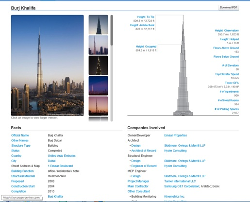

## Scrapy can help

[figure not shown]

Sorry, not that (above) Scrappy, but this (below) Scrapy

[figure not shown]

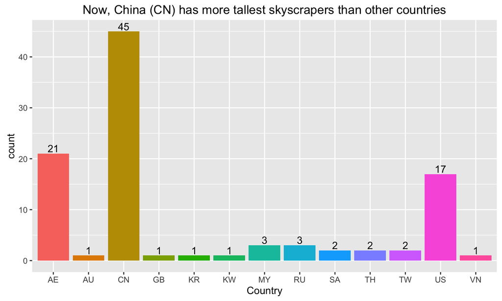

| ct cc country | ct cc country | ct cc country |
| --- | --- | --- |
| 21 AE Arab Emirates | 01 AU Australia | 45 CN China |
| 01 GB United Kingdom | 01 KR South Korea | 01 KW Kuwait |
| 03 MY Malaysia | 03 RU Russia | 02 SA Saudi Arabia |
| 02 TH Thailand | 02 TW Taiwan | 17 US USA |
| 01 VN Vietnam |  |  |

## Statistics about these 100 skyscrapers:

- Usages
  - 40 are multipurpose.
  - 74 are used for office.
  - 43 are used for hotel.
  - 29 are used for residential.
  - 2 are used for retail.
- Totals
  - 7758 floors.
  - 118653 feet.

## Time

- 46 do not have Proposed Year listed.
- 3 do not have Construction Start Year listed.
- From Proposed To Construction Start:
  - Cannot compute 46.
  - Shortest took 0 year.
  - Longest took 9 year.
- From Construction Start To Complete:
  - Cannot compute 3.
  - Shortest took *1* year.
  - Longest took 11 year.

One year to build a skyscraper! Really?

## No kidding. Actually there are 2 :

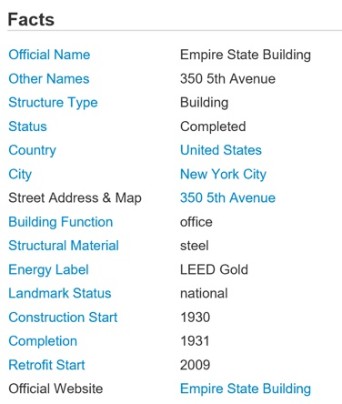

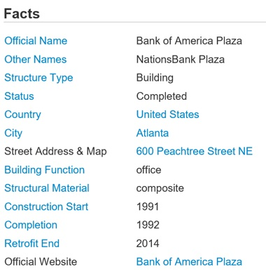

[figure not shown]

Please check my blog [Let Scrape the Skyscrapers using Scrapy](http://blog.nycdatascience.com/student-works/let-scrape-skyscrapers-using-scrapy/) for more information on using Scrapy.

Best wishes,  
Conred Wang.